# Praca domowa 2

Paweł Wicherek

3/26/2020

# Praca domowa 2

Dane dotyczą cen nieruchomości w hrabstwie King w stanie Washington. Wybrałem ten temat, gdyż ten temat jest mi poniekąd bliski — chcąc nie chcąc oglądałem często programy typu ,,Property brothers’’, więc też dowiedziałem się nieco o samym temacie.

### Przygotowanie danych

```r
library(DALEX)
library(iml)
library(iBreakDown)
library(dplyr)
library(randomForest)
```

```r
df <- read.csv("kc_house_data.csv",header=TRUE)
df <- df%>% select(-id)
df$date <- as.integer(stringi::stri_sub(df$date,from=1L, to=8L))
head(df)
```

```
##       date   price bedrooms bathrooms sqft_living sqft_lot floors waterfront
## 1 20141013  221900        3      1.00        1180     5650      1          0
## 2 20141209  538000        3      2.25        2570     7242      2          0
## 3 20150225  180000        2      1.00         770    10000      1          0
## 4 20141209  604000        4      3.00        1960     5000      1          0
## 5 20150218  510000        3      2.00        1680     8080      1          0
## 6 20140512 1225000        4      4.50        5420   101930      1          0
##   view condition grade sqft_above sqft_basement yr_built yr_renovated zipcode
## 1    0         3     7       1180             0     1955            0   98178
## 2    0         3     7       2170           400     1951         1991   98125
## 3    0         3     6        770             0     1933            0   98028
## 4    0         5     7       1050           910     1965            0   98136
## 5    0         3     8       1680             0     1987            0   98074
## 6    0         3    11       3890          1530     2001            0   98053
##       lat     long sqft_living15 sqft_lot15
## 1 47.5112 -122.257          1340       5650
## 2 47.7210 -122.319          1690       7639
## 3 47.7379 -122.233          2720       8062
## 4 47.5208 -122.393          1360       5000
## 5 47.6168 -122.045          1800       7503
## 6 47.6561 -122.005          4760     101930
```

Przygotowanie próby uczącej i testowej,

```r
set.seed(484)
N <- length(df$price)
s <- sample(N)
k <- round(0.7*N)
s_train <- s[1:k]
s_test <- s[-c(1:k)]

df_train <- df[s_train,]
df_test <- df[s_test,]
y_train <- df_train$price
X_train <- df_train %>% select(-price)
```

### Zadanie 1,2

```r
rf_m1 <- randomForest::randomForest(price~., data=df_train)

A <- df_test[1,]
print(predict(rf_m1, newdata=A) )
print(A$price)
```

```
##     7370
## 304886.3
```

```
## [1] 295000
```

### Zadanie 3

Shap

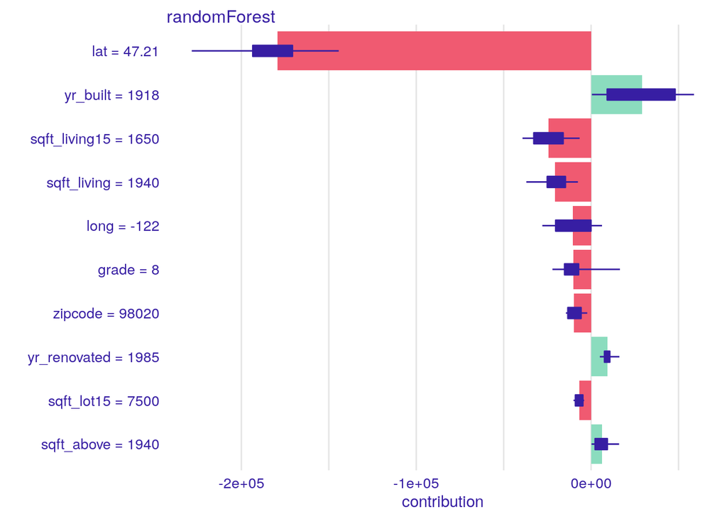

```r
exp1 <- DALEX::explain(rf_m1)
output1 <- DALEX::predict_parts_shap(exp2,A)
plot(output1)
```

Break Down

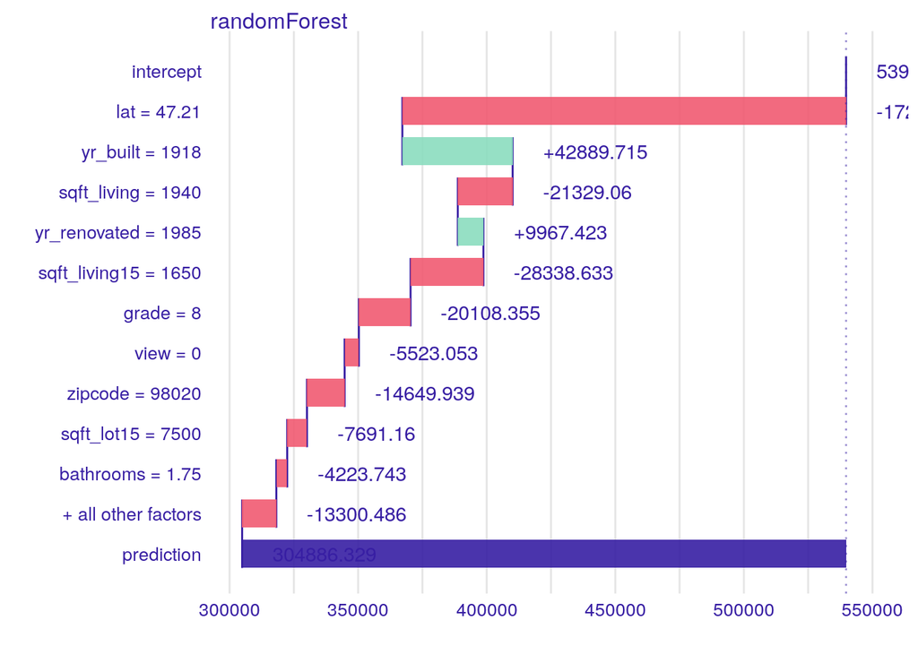

```r
bd1 <- break_down(exp1,new_observation=A)
plot(bd1)
```

### Zadanie 4

find two observations in the data set, such that they have different most important variables (e.g. age and gender are the most important for observation A, but race and class for observation B)

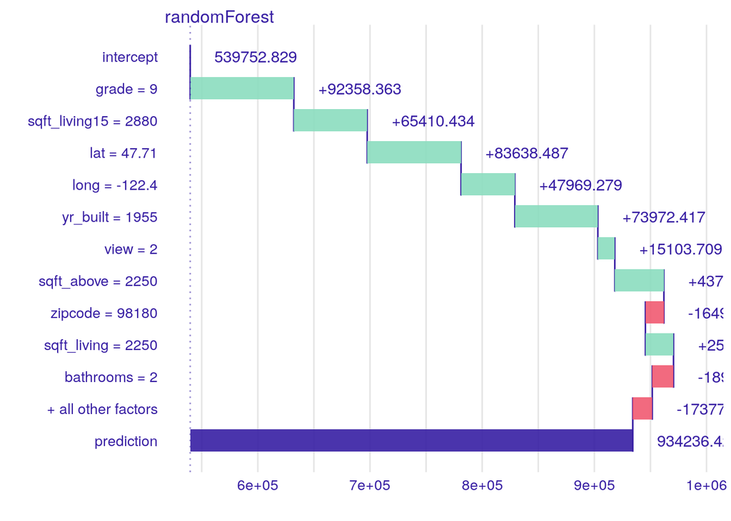

```r
A <- df_test[1,]
B <- df_test[2,]

bd2 <- break_down(exp2,new_observation=B)
plot(bd2)
```

B ma najważniejsze istotne jakość mieszkania oraz powierzchnię, natomiast A ma położenie oraz rok budowy.

### Zadanie 5

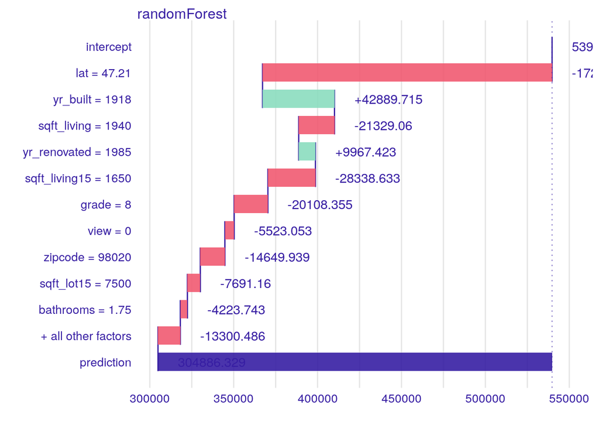

```r
plot(bd1)
```

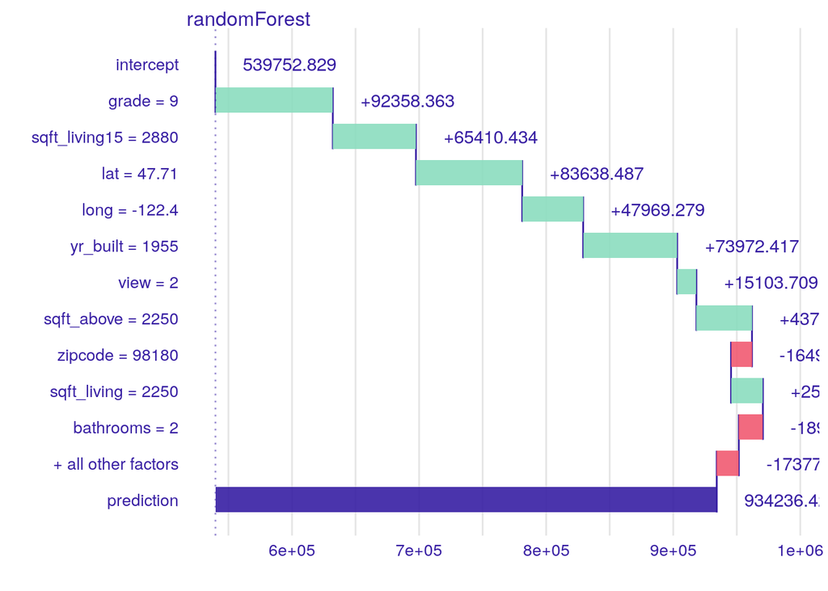

```r
plot(bd2)
```

`lat` ma pozytywny i negatywny wpływ.

### Zadanie 6

```
## Preparation of a new explainer is initiated
##   -> model label       :  lm  (  default  )
##   -> data              :  15129  rows  20  cols  extracted from the model
##   -> target variable   :  not specified! (  WARNING  )
##   -> model_info        :  package stats , ver. 3.6.1 , task regression (  default  )
##   -> predict function  :  yhat.lm  will be used (  default  )
##   -> predicted values  :  numerical, min =  -542040.6 , mean =  539740.6 , max =  3384108
##   -> residual function :  difference between y and yhat (  default  )
##   A new explainer has been created!
```

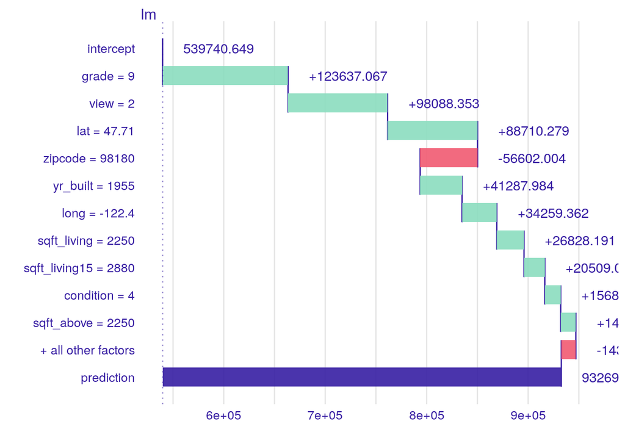

```r
m_lin <- lm(price~., data=df_train)
exp_lin <- DALEX::explain(m_lin)

bd_lin_1 <- break_down(exp_lin,new_observation=A)
plot(bd_lin_1)
bd_lin_2 <- break_down(exp_lin,new_observation=B)
plot(bd_lin_2)
```

[output not shown]

### Zadanie 7

Zrobiliśmy wyjaśnienie dla różnych modeli, dla różnych obserwacji, różnymi metodami. Zauważyliśmy, że wyniki mogą się od siebie różnić. Wyjaśnienia się mogą różnić w zależności od modelu i metody wyjaśniania, nawet dla tej samej obserwacji.